# Use Scikit-learn to predict car price

| **Use scikit-learn to predict the price of a Car** |  |
| --- | --- |

This notebook gives an insight on how to handle regression problems in data science. In machine learning, regression is used when the target (the variable that will be predicted) is numerical. There are various regression algorithms that can be used to predict numerical data and you will compare the results of three of them below.

In this notebook, you will use a data set of auto imports to predict the price of a car. This data set has 205 records, and you will split them into the training and testing sets after the data is loaded and cleaned. You will learn what steps to take to explore and prepare the data, create a model, and use Watson Machine Learning Client to save and deploy the model to the IBM Cloud.

The notebook uses `scikit-learn 0.20` and `watson-machine-learning-client-V4`.

Some familiarity with Python is helpful. This notebook is compatible with Watson Studio Local 2.1 and Python 3.6.

## Learning goals

- Load csv data.
- Display data using PixieDust.
- Explore data.
  - Handle missing values.
  - Visualize data in order to find significant predictors.
- Prepare data for training.
  - Train-test split.
  - One-hot encoding.
  - Feature scaling.
- Create, compare, and evaluate models.
- Use grid search to tune the model hyperparameters.
- Use Watson Machine Learning Client package.
  - Save, deploy, and score the selected model.
1. Set up your environment
2. Load and explore data  
   2.1 Explore data  
   2.2 EDA and Feature selection
3. Data preparation  
   3.1 One-hot encoding  
   3.2 Feature scaling
4. Model selection  
   4.1 Compare and evaluate models  
   4.2 Grid search  
   4.3 Evaluate final model
5. Manage models in the WML Repository  
   5.1 Authenticate  
   5.2 Save the model in the WML repository  
   5.3 Load the model from the WML repository
6. Deploy the selected model and score data  
   6.1 Create a batch deployment for the published model  
   6.2 Score data  
   6.3 Delete the deployment and model
7. Summary and next steps

## 1. Set up your environment

To get started on Watson Studio Local 2.1, read the documentation on installion and set up.

## 2. Load and explore data

In this section, the following topics will be covered:

- 2.1 Explore data
- 2.2 EDA and Feature selection

### 2.1 Explore data

Load the data from the [Auto Imports Database](https://archive.ics.uci.edu/ml/datasets/automobile) available on UCI Machine Learning.

You can use PixieDust to display items such as tables. PixieDust is an IBM open source add-on tool for Jupyter Notebooks used to explore and visualize data in such a way that it's easy to share and gather information from.

1. To avoid re-installation when re-running the notebook, try running your notebooks in custom environments. To find out more about setting up custom environments, see [here](https://www.ibm.com/support/knowledgecenter/SSQNUZ_current/wsj/analyze-data/customize-envs.html).  
2. To simply hide the output of pip install instead, use `-q` after `!pip install`.

```python
# Install pixiedust.
!pip install --upgrade pixiedust
```

[output not shown]

```python
# Import modules.
import numpy as np
import pandas as pd
import pixiedust

# Load data and set column names.
cars_data = pd.read_csv('https://archive.ics.uci.edu/ml/machine-learning-databases/autos/imports-85.data',
                        names = ['symboling', 'normalized-losses', 'make', 'fuel-type', 'aspiration', 'num-of-doors',
                                 'body-style', 'drive-wheels', 'engine-location', 'wheel-base', 'length', 'width', 'height',
                                 'curb-weight', 'engine-type', 'num-of-cylinders', 'engine-size', 'fuel-system', 'bore',
                                 'stroke', 'compression-ratio', 'horsepower', 'peak-rpm', 'city-mpg', 'highway-mpg', 'price'])
display(cars_data.head(10))
```

**Schema**

Field types:

**symboling:** int64

**normalized-losses:** float64

**make:** object

**fuel-type:** object

**aspiration:** object

**num-of-doors:** object

**body-style:** object

**drive-wheels:** object

**engine-location:** object

**wheel-base:** float64

**length:** float64

**width:** float64

**height:** float64

**curb-weight:** int64

**engine-type:** object

**num-of-cylinders:** object

**engine-size:** int64

**fuel-system:** object

**bore:** float64

**stroke:** float64

**compression-ratio:** float64

**horsepower:** float64

**peak-rpm:** float64

**city-mpg:** int64

**highway-mpg:** int64

**price:** float64

**Table**

Showing 10 of 10 rows

symboling

normalized-losses

make

fuel-type

aspiration

num-of-doors

body-style

drive-wheels

engine-location

wheel-base

length

width

height

curb-weight

engine-type

num-of-cylinders

engine-size

fuel-system

bore

stroke

compression-ratio

horsepower

peak-rpm

city-mpg

highway-mpg

price

| symboling | normalized-losses | make | fuel-type | aspiration | num-of-doors | body-style | drive-wheels | engine-location | wheel-base | length | width | height | curb-weight | engine-type | num-of-cylinders | engine-size | fuel-system | bore | stroke | compression-ratio | horsepower | peak-rpm | city-mpg | highway-mpg | price |
| --- | --- | --- | --- | --- | --- | --- | --- | --- | --- | --- | --- | --- | --- | --- | --- | --- | --- | --- | --- | --- | --- | --- | --- | --- | --- |
| 3 | nan | alfa-romero | gas | std | two | convertible | rwd | front | 88.6 | 168.8 | 64.1 | 48.8 | 2548 | dohc | four | 130 | mpfi | 3.47 | 2.68 | 9.0 | 111.0 | 5000.0 | 21 | 27 | 13495.0 |
| 3 | nan | alfa-romero | gas | std | two | convertible | rwd | front | 88.6 | 168.8 | 64.1 | 48.8 | 2548 | dohc | four | 130 | mpfi | 3.47 | 2.68 | 9.0 | 111.0 | 5000.0 | 21 | 27 | 16500.0 |
| 1 | nan | alfa-romero | gas | std | two | hatchback | rwd | front | 94.5 | 171.2 | 65.5 | 52.4 | 2823 | ohcv | six | 152 | mpfi | 2.68 | 3.47 | 9.0 | 154.0 | 5000.0 | 19 | 26 | 16500.0 |
| 2 | 164.0 | audi | gas | std | four | sedan | fwd | front | 99.8 | 176.6 | 66.2 | 54.3 | 2337 | ohc | four | 109 | mpfi | 3.19 | 3.4 | 10.0 | 102.0 | 5500.0 | 24 | 30 | 13950.0 |
| 2 | 164.0 | audi | gas | std | four | sedan | 4wd | front | 99.4 | 176.6 | 66.4 | 54.3 | 2824 | ohc | five | 136 | mpfi | 3.19 | 3.4 | 8.0 | 115.0 | 5500.0 | 18 | 22 | 17450.0 |
| 2 | nan | audi | gas | std | two | sedan | fwd | front | 99.8 | 177.3 | 66.3 | 53.1 | 2507 | ohc | five | 136 | mpfi | 3.19 | 3.4 | 8.5 | 110.0 | 5500.0 | 19 | 25 | 15250.0 |
| 1 | 158.0 | audi | gas | std | four | sedan | fwd | front | 105.8 | 192.7 | 71.4 | 55.7 | 2844 | ohc | five | 136 | mpfi | 3.19 | 3.4 | 8.5 | 110.0 | 5500.0 | 19 | 25 | 17710.0 |
| 1 | nan | audi | gas | std | four | wagon | fwd | front | 105.8 | 192.7 | 71.4 | 55.7 | 2954 | ohc | five | 136 | mpfi | 3.19 | 3.4 | 8.5 | 110.0 | 5500.0 | 19 | 25 | 18920.0 |
| 1 | 158.0 | audi | gas | turbo | four | sedan | fwd | front | 105.8 | 192.7 | 71.4 | 55.9 | 3086 | ohc | five | 131 | mpfi | 3.13 | 3.4 | 8.3 | 140.0 | 5500.0 | 17 | 20 | 23875.0 |
| 2 | 192.0 | bmw | gas | std | two | sedan | rwd | front | 101.2 | 176.8 | 64.8 | 54.3 | 2395 | ohc | four | 108 | mpfi | 3.5 | 2.8 | 8.8 | 101.0 | 5800.0 | 23 | 29 | 16430.0 |

Here, you see a preview of the first 10 rows of the data. You can look at the values to get a sense of each column's data type. Also, taking note of the "?" values in some rows, you can infer that there are missing values in this data set. These will be handled later in this notebook.

Run the cell below to get a list of the columns and their automatically assigned data types.

```python
# Observe column data types.
cars_data.info()
```

```
<class 'pandas.core.frame.DataFrame'>
RangeIndex: 205 entries, 0 to 204
Data columns (total 26 columns):
symboling            205 non-null int64
normalized-losses    205 non-null object
make                 205 non-null object
fuel-type            205 non-null object
aspiration           205 non-null object
num-of-doors         205 non-null object
body-style           205 non-null object
drive-wheels         205 non-null object
engine-location      205 non-null object
wheel-base           205 non-null float64
length               205 non-null float64
width                205 non-null float64
height               205 non-null float64
curb-weight          205 non-null int64
engine-type          205 non-null object
num-of-cylinders     205 non-null object
engine-size          205 non-null int64
fuel-system          205 non-null object
bore                 205 non-null object
stroke               205 non-null object
compression-ratio    205 non-null float64
horsepower           205 non-null object
peak-rpm             205 non-null object
city-mpg             205 non-null int64
highway-mpg          205 non-null int64
price                205 non-null object
dtypes: float64(5), int64(5), object(16)
memory usage: 41.7+ KB
```

```python
# Display the number of records and features.
print('Number of rows: {}'.format(len(cars_data)))
print('Number of columns: {}'.format(len(cars_data.columns)))
```

```
Number of rows: 205
Number of columns: 26
```

The data set has 205 records and 26 features. As you can see, some of the data types are incorrectly marked as objects due to the missing values (represented by "?"). This can be fixed by running the following code, which converts the data type of the selected columns to numeric, replacing each missing value "?" with NaN.

```python
# Fix column data types.
cars_data[['normalized-losses', 'bore', 'stroke', 'horsepower', 'peak-rpm', 'price']] = cars_data[['normalized-losses', 'bore', 'stroke', 'horsepower', 'peak-rpm', 'price']].apply(pd.to_numeric, errors='coerce', axis=1)
display(cars_data.head())
```

**Schema**

Field types:

**symboling:** int64

**normalized-losses:** float64

**make:** object

**fuel-type:** object

**aspiration:** object

**num-of-doors:** object

**body-style:** object

**drive-wheels:** object

**engine-location:** object

**wheel-base:** float64

**length:** float64

**width:** float64

**height:** float64

**curb-weight:** int64

**engine-type:** object

**num-of-cylinders:** object

**engine-size:** int64

**fuel-system:** object

**bore:** float64

**stroke:** float64

**compression-ratio:** float64

**horsepower:** float64

**peak-rpm:** float64

**city-mpg:** int64

**highway-mpg:** int64

**price:** float64

**Table**

Showing 5 of 5 rows

symboling

normalized-losses

make

fuel-type

aspiration

num-of-doors

body-style

drive-wheels

engine-location

wheel-base

length

width

height

curb-weight

engine-type

num-of-cylinders

engine-size

fuel-system

bore

stroke

compression-ratio

horsepower

peak-rpm

city-mpg

highway-mpg

price

| symboling | normalized-losses | make | fuel-type | aspiration | num-of-doors | body-style | drive-wheels | engine-location | wheel-base | length | width | height | curb-weight | engine-type | num-of-cylinders | engine-size | fuel-system | bore | stroke | compression-ratio | horsepower | peak-rpm | city-mpg | highway-mpg | price |
| --- | --- | --- | --- | --- | --- | --- | --- | --- | --- | --- | --- | --- | --- | --- | --- | --- | --- | --- | --- | --- | --- | --- | --- | --- | --- |
| 3 | nan | alfa-romero | gas | std | two | convertible | rwd | front | 88.6 | 168.8 | 64.1 | 48.8 | 2548 | dohc | four | 130 | mpfi | 3.47 | 2.68 | 9.0 | 111.0 | 5000.0 | 21 | 27 | 13495.0 |
| 3 | nan | alfa-romero | gas | std | two | convertible | rwd | front | 88.6 | 168.8 | 64.1 | 48.8 | 2548 | dohc | four | 130 | mpfi | 3.47 | 2.68 | 9.0 | 111.0 | 5000.0 | 21 | 27 | 16500.0 |
| 1 | nan | alfa-romero | gas | std | two | hatchback | rwd | front | 94.5 | 171.2 | 65.5 | 52.4 | 2823 | ohcv | six | 152 | mpfi | 2.68 | 3.47 | 9.0 | 154.0 | 5000.0 | 19 | 26 | 16500.0 |
| 2 | 164.0 | audi | gas | std | four | sedan | fwd | front | 99.8 | 176.6 | 66.2 | 54.3 | 2337 | ohc | four | 109 | mpfi | 3.19 | 3.4 | 10.0 | 102.0 | 5500.0 | 24 | 30 | 13950.0 |
| 2 | 164.0 | audi | gas | std | four | sedan | 4wd | front | 99.4 | 176.6 | 66.4 | 54.3 | 2824 | ohc | five | 136 | mpfi | 3.19 | 3.4 | 8.0 | 115.0 | 5500.0 | 18 | 22 | 17450.0 |

The missing values in each column can be counted using the following code.

```python
# Check for missing values.
cars_data.isnull().sum()
```

```
symboling             0
normalized-losses    41
make                  0
fuel-type             0
aspiration            0
num-of-doors          0
body-style            0
drive-wheels          0
engine-location       0
wheel-base            0
length                0
width                 0
height                0
curb-weight           0
engine-type           0
num-of-cylinders      0
engine-size           0
fuel-system           0
bore                  4
stroke                4
compression-ratio     0
horsepower            2
peak-rpm              2
city-mpg              0
highway-mpg           0
price                 4
dtype: int64
```

The output shows us that the label, *price*, is missing in 4 rows. Since you cannot make and evaluate predictions without the labels, those rows can be removed using the cell below.

```python
# Drop rows with missing target values.
cars_data.dropna(subset=['price'], inplace = True)
cars_data.isnull().sum()
```

```
symboling             0
normalized-losses    37
make                  0
fuel-type             0
aspiration            0
num-of-doors          0
body-style            0
drive-wheels          0
engine-location       0
wheel-base            0
length                0
width                 0
height                0
curb-weight           0
engine-type           0
num-of-cylinders      0
engine-size           0
fuel-system           0
bore                  4
stroke                4
compression-ratio     0
horsepower            2
peak-rpm              2
city-mpg              0
highway-mpg           0
price                 0
dtype: int64
```

Import the packages below to use for the exploratory data analysis.

```python
# Import visualization packages.
import matplotlib.pyplot as plt
import seaborn as sns
```

You can visualize the price distribution of the cars by running the following cell.

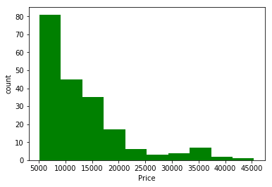

```python
# Distribution of target value price.
plt.hist(x = cars_data['price'], bins = 10, color = 'green')
plt.xlabel('Price')
plt.ylabel('count')
```

Now, look at the distribution of the columns *with* their missing values and compare them to the column distributions once the missing values are replaced by the the column **mean**.

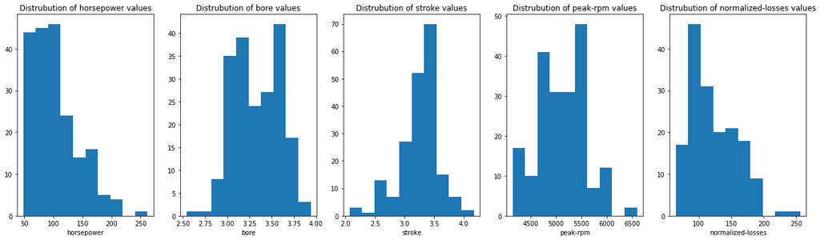

```python
# Histograms of columns with missing values.
f, ((ax1, ax2, ax3, ax4, ax5)) = plt.subplots(1, 5, figsize=(18,5))
f.tight_layout()
ax = [ax1, ax2, ax3, ax4, ax5]
col = ['horsepower', 'bore', 'stroke', 'peak-rpm', 'normalized-losses']
for i in range (len(ax)):
    x_hist = cars_data[col[i]].dropna(inplace=False)

    ax[i].hist(x = x_hist, bins = 10)
    ax[i].set_xlabel(col[i])
    ax[i].set_title('Distrubution of ' + col[i] + ' values')
```

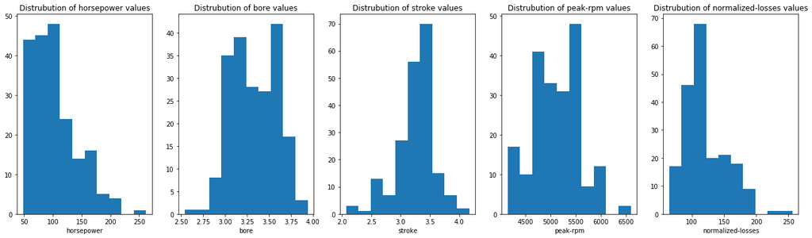

```python
# Histograms of columns with adjusted missing values.
f, ((ax1, ax2, ax3, ax4, ax5)) = plt.subplots(1, 5, figsize=(18,5))
f.tight_layout()
ax = [ax1, ax2, ax3, ax4, ax5]
col = ['horsepower', 'bore', 'stroke', 'peak-rpm', 'normalized-losses']
for i in range (len(ax)):
    x_hist = cars_data[col[i]].fillna(value=cars_data[col[i]].mean(), inplace=False)

    ax[i].hist(x = x_hist, bins = 10)
    ax[i].set_xlabel(col[i])
    ax[i].set_title('Distrubution of ' + col[i] + ' values')
```

The distribution does not change significantly for *horsepower*, *bore*, *stroke*, and *peak-rpm*, so for these columns, this method can be used to replace the missing values without significantly affecting the predictions.

```python
for col in ['horsepower', 'bore', 'stroke', 'peak-rpm']:
    cars_data[col].fillna(cars_data[col].mean(), inplace=True)
```

### 2.2 EDA and Feature selection

In order to make accurate predictions, you need to select the significant numerical predictors by choosing the features most highly correlated to the label, *price*.

```python
# Correlation of numerical values.
cars_data.corr()
```

|  | symboling | normalized-losses | wheel-base | length | width | height | curb-weight | engine-size | bore | stroke | compression-ratio | horsepower | peak-rpm | city-mpg | highway-mpg | price |
| --- | --- | --- | --- | --- | --- | --- | --- | --- | --- | --- | --- | --- | --- | --- | --- | --- |
| symboling | 1.000000 | 0.528667 | -0.535987 | -0.365404 | -0.242423 | -0.550160 | -0.233118 | -0.110581 | -0.139896 | -0.007992 | -0.182196 | 0.075790 | 0.279719 | -0.035527 | 0.036233 | -0.082391 |
| normalized-losses | 0.528667 | 1.000000 | -0.074362 | 0.023220 | 0.105073 | -0.432335 | 0.119893 | 0.167365 | -0.033506 | 0.066413 | -0.132654 | 0.295772 | 0.264597 | -0.258502 | -0.210768 | 0.203254 |
| wheel-base | -0.535987 | -0.074362 | 1.000000 | 0.876024 | 0.814507 | 0.590742 | 0.782097 | 0.572027 | 0.493203 | 0.157964 | 0.250313 | 0.371250 | -0.360233 | -0.470606 | -0.543304 | 0.584642 |
| length | -0.365404 | 0.023220 | 0.876024 | 1.000000 | 0.857170 | 0.492063 | 0.880665 | 0.685025 | 0.608941 | 0.123913 | 0.159733 | 0.579731 | -0.286035 | -0.665192 | -0.698142 | 0.690628 |
| width | -0.242423 | 0.105073 | 0.814507 | 0.857170 | 1.000000 | 0.306002 | 0.866201 | 0.729436 | 0.544879 | 0.188814 | 0.189867 | 0.615006 | -0.245852 | -0.633531 | -0.680635 | 0.751265 |
| height | -0.550160 | -0.432335 | 0.590742 | 0.492063 | 0.306002 | 1.000000 | 0.307581 | 0.074694 | 0.180327 | -0.060822 | 0.259737 | -0.086941 | -0.309913 | -0.049800 | -0.104812 | 0.135486 |
| curb-weight | -0.233118 | 0.119893 | 0.782097 | 0.880665 | 0.866201 | 0.307581 | 1.000000 | 0.849072 | 0.644041 | 0.167412 | 0.156433 | 0.757994 | -0.279350 | -0.749543 | -0.794889 | 0.834415 |
| engine-size | -0.110581 | 0.167365 | 0.572027 | 0.685025 | 0.729436 | 0.074694 | 0.849072 | 1.000000 | 0.572516 | 0.205806 | 0.028889 | 0.822649 | -0.256753 | -0.650546 | -0.679571 | 0.872335 |
| bore | -0.139896 | -0.033506 | 0.493203 | 0.608941 | 0.544879 | 0.180327 | 0.644041 | 0.572516 | 1.000000 | -0.055390 | 0.001250 | 0.566838 | -0.267338 | -0.582121 | -0.591390 | 0.543154 |
| stroke | -0.007992 | 0.066413 | 0.157964 | 0.123913 | 0.188814 | -0.060822 | 0.167412 | 0.205806 | -0.055390 | 1.000000 | 0.187854 | 0.097815 | -0.063720 | -0.034079 | -0.034741 | 0.082267 |
| compression-ratio | -0.182196 | -0.132654 | 0.250313 | 0.159733 | 0.189867 | 0.259737 | 0.156433 | 0.028889 | 0.001250 | 0.187854 | 1.000000 | -0.214431 | -0.435721 | 0.331425 | 0.268465 | 0.071107 |
| horsepower | 0.075790 | 0.295772 | 0.371250 | 0.579731 | 0.615006 | -0.086941 | 0.757994 | 0.822649 | 0.566838 | 0.097815 | -0.214431 | 1.000000 | 0.107882 | -0.822138 | -0.804587 | 0.809681 |
| peak-rpm | 0.279719 | 0.264597 | -0.360233 | -0.286035 | -0.245852 | -0.309913 | -0.279350 | -0.256753 | -0.267338 | -0.063720 | -0.435721 | 0.107882 | 1.000000 | -0.115358 | -0.058605 | -0.101542 |
| city-mpg | -0.035527 | -0.258502 | -0.470606 | -0.665192 | -0.633531 | -0.049800 | -0.749543 | -0.650546 | -0.582121 | -0.034079 | 0.331425 | -0.822138 | -0.115358 | 1.000000 | 0.972044 | -0.686571 |
| highway-mpg | 0.036233 | -0.210768 | -0.543304 | -0.698142 | -0.680635 | -0.104812 | -0.794889 | -0.679571 | -0.591390 | -0.034741 | 0.268465 | -0.804587 | -0.058605 | 0.972044 | 1.000000 | -0.704692 |
| price | -0.082391 | 0.203254 | 0.584642 | 0.690628 | 0.751265 | 0.135486 | 0.834415 | 0.872335 | 0.543154 | 0.082267 | 0.071107 | 0.809681 | -0.101542 | -0.686571 | -0.704692 | 1.000000 |

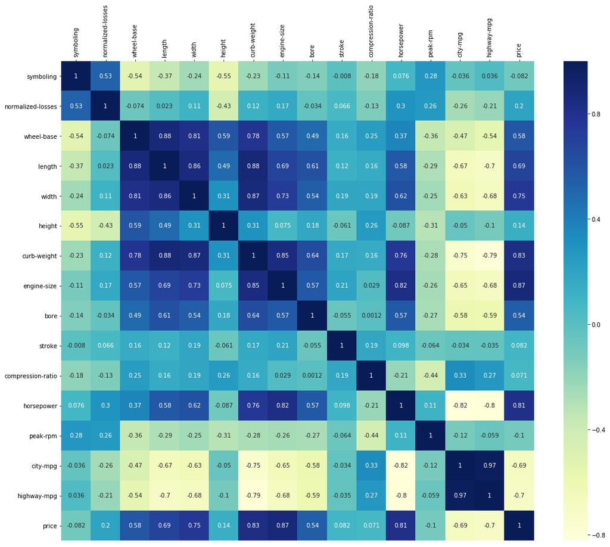

```python
# Plot a correlation heatmap.
plt.subplots(figsize=(18,15))
hm1 = sns.heatmap(cars_data.corr(), annot=True, cmap='YlGnBu')
hm1.set_xticklabels(hm1.get_xticklabels(), rotation=90)
hm1.xaxis.set_ticks_position('top')
```

Although the *normalized-losses* column has many NaNs, it doesn't appear to be a significant predictor. So, the missing values do not need to be filled in this case.

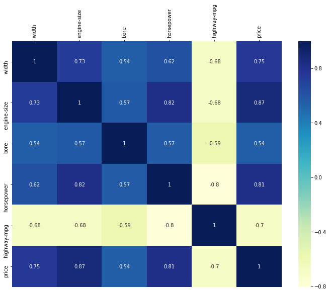

```python
# Plot correlation heatmap of selected numerical features.
plt.subplots(figsize=(12, 9))
hm2 = sns.heatmap(cars_data[['width', 'engine-size', 'bore', 'horsepower', 'highway-mpg', 'price']].corr(), annot=True, cmap='YlGnBu')
hm2.set_xticklabels(hm2.get_xticklabels(), rotation=90)
hm2.xaxis.set_ticks_position('top')
```

By plotting the boxplots of each categorical column against the price, you can pick out the significant features. More variation in the boxplot implies higher significance. Therefore you can choose *make*, *engine-location*, *num-of-cylinders*, and *fuel-system* as predictors for the model.

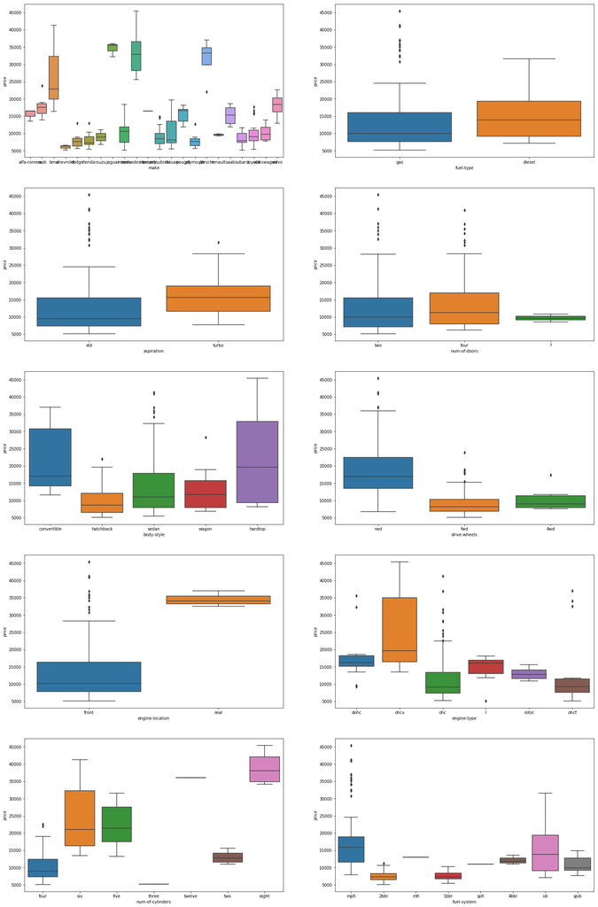

```python
# Plot boxplots of categorical columns.
cat_list = ['make', 'fuel-type', 'aspiration', 'num-of-doors', 'body-style', 'drive-wheels', 'engine-location', 'engine-type', 'num-of-cylinders', 'fuel-system']
f, ((ax1, ax2), (ax3, ax4), (ax5, ax6), (ax7, ax8), (ax9, ax10)) = plt.subplots(5, 2, figsize=(25, 40))
ax = [ax1, ax2, ax3, ax4, ax5, ax6, ax7, ax8, ax9, ax10]

for i in range(len(cat_list)):
    sns.boxplot(x = cat_list[i], y = 'price', data=cars_data, ax=ax[i])
```

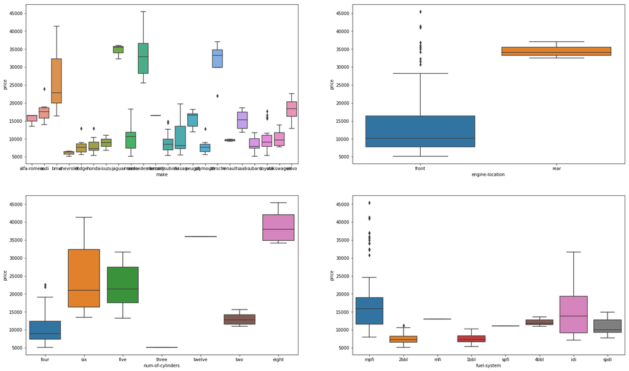

```python
# Plot boxplots of selected categorical columns:
# drive-wheels, engine-type.
cat_list2 = ['make', 'engine-location', 'num-of-cylinders', 'fuel-system']
f, ((ax1, ax2), (ax3, ax4)) = plt.subplots(2, 2, figsize=(25, 15))
ax = [ax1, ax2, ax3, ax4]

for i in range(len(cat_list2)):
    sns.boxplot(x = cat_list2[i], y = 'price', data=cars_data, ax=ax[i])
```

## 3. Data Preparation

This section will cover:

- 3.1 One-hot encoding
- 3.2 Feature scaling

### 3.1 One-hot encoding

Now, the predictors can be set to a variable X and the target/label to variable y.

```python
# Feature selection.
X = cars_data[['make', 'engine-location', 'width', 'num-of-cylinders', 'engine-size', 'fuel-system', 'bore', 'horsepower', 'highway-mpg']]
y = cars_data.iloc[:, 25]
```

Many models take only numerical values as input. So, using the following code, the categorical columns are converted to dummy variables, a process called **one-hot encoding**. This means that each column is split into it's various categories, with a column of binary values for each category. One category/column is always omitted from each set of categories to prevent multicollinearity.

For example, *engine-location* as 2 categories: *front* and *rear*. This is converted into 2 colums - one for each category - but one is dropped, leaving only *engine-location_rear*. The model will infer from this that '1' represents the *rear* category and '0' represents the *front* category.

```python
# One-hot encoding.
X = pd.get_dummies(X, columns=['make', 'engine-location', 'num-of-cylinders', 'fuel-system'], drop_first=True)
X_copy = X.copy()
```

```python
X = X.values
```

You can check the one-hot encoded columns.

```python
with pd.option_context('display.max_columns', None):
    display(X_copy.head())
```

**Schema**

Field types:

**width:** float64

**engine-size:** int64

**bore:** float64

**horsepower:** float64

**highway-mpg:** int64

**make_audi:** uint8

**make_bmw:** uint8

**make_chevrolet:** uint8

**make_dodge:** uint8

**make_honda:** uint8

**make_isuzu:** uint8

**make_jaguar:** uint8

**make_mazda:** uint8

**make_mercedes-benz:** uint8

**make_mercury:** uint8

**make_mitsubishi:** uint8

**make_nissan:** uint8

**make_peugot:** uint8

**make_plymouth:** uint8

**make_porsche:** uint8

**make_renault:** uint8

**make_saab:** uint8

**make_subaru:** uint8

**make_toyota:** uint8

**make_volkswagen:** uint8

**make_volvo:** uint8

**engine-location_rear:** uint8

**num-of-cylinders_five:** uint8

**num-of-cylinders_four:** uint8

**num-of-cylinders_six:** uint8

**num-of-cylinders_three:** uint8

**num-of-cylinders_twelve:** uint8

**num-of-cylinders_two:** uint8

**fuel-system_2bbl:** uint8

**fuel-system_4bbl:** uint8

**fuel-system_idi:** uint8

**fuel-system_mfi:** uint8

**fuel-system_mpfi:** uint8

**fuel-system_spdi:** uint8

**fuel-system_spfi:** uint8

**Table**

Showing 5 of 5 rows

width

engine-size

bore

horsepower

highway-mpg

make_audi

make_bmw

make_chevrolet

make_dodge

make_honda

make_isuzu

make_jaguar

make_mazda

make_mercedes-benz

make_mercury

make_mitsubishi

make_nissan

make_peugot

make_plymouth

make_porsche

make_renault

make_saab

make_subaru

make_toyota

make_volkswagen

make_volvo

engine-location_rear

num-of-cylinders_five

num-of-cylinders_four

num-of-cylinders_six

num-of-cylinders_three

num-of-cylinders_twelve

num-of-cylinders_two

fuel-system_2bbl

fuel-system_4bbl

fuel-system_idi

fuel-system_mfi

fuel-system_mpfi

fuel-system_spdi

fuel-system_spfi

| width | engine-size | bore | horsepower | highway-mpg | make_audi | make_bmw | make_chevrolet | make_dodge | make_honda | make_isuzu | make_jaguar | make_mazda | make_mercedes-benz | make_mercury | make_mitsubishi | make_nissan | make_peugot | make_plymouth | make_porsche | make_renault | make_saab | make_subaru | make_toyota | make_volkswagen | make_volvo | engine-location_rear | num-of-cylinders_five | num-of-cylinders_four | num-of-cylinders_six | … |
| --- | --- | --- | --- | --- | --- | --- | --- | --- | --- | --- | --- | --- | --- | --- | --- | --- | --- | --- | --- | --- | --- | --- | --- | --- | --- | --- | --- | --- | --- | --- |
| 64.1 | 130.0 | 3.47 | 111.0 | 27.0 | 0.0 | 0.0 | 0.0 | 0.0 | 0.0 | 0.0 | 0.0 | 0.0 | 0.0 | 0.0 | 0.0 | 0.0 | 0.0 | 0.0 | 0.0 | 0.0 | 0.0 | 0.0 | 0.0 | 0.0 | 0.0 | 0.0 | 0.0 | 1.0 | 0.0 | … |
| 64.1 | 130.0 | 3.47 | 111.0 | 27.0 | 0.0 | 0.0 | 0.0 | 0.0 | 0.0 | 0.0 | 0.0 | 0.0 | 0.0 | 0.0 | 0.0 | 0.0 | 0.0 | 0.0 | 0.0 | 0.0 | 0.0 | 0.0 | 0.0 | 0.0 | 0.0 | 0.0 | 0.0 | 1.0 | 0.0 | … |
| 65.5 | 152.0 | 2.68 | 154.0 | 26.0 | 0.0 | 0.0 | 0.0 | 0.0 | 0.0 | 0.0 | 0.0 | 0.0 | 0.0 | 0.0 | 0.0 | 0.0 | 0.0 | 0.0 | 0.0 | 0.0 | 0.0 | 0.0 | 0.0 | 0.0 | 0.0 | 0.0 | 0.0 | 0.0 | 1.0 | … |
| 66.2 | 109.0 | 3.19 | 102.0 | 30.0 | 1.0 | 0.0 | 0.0 | 0.0 | 0.0 | 0.0 | 0.0 | 0.0 | 0.0 | 0.0 | 0.0 | 0.0 | 0.0 | 0.0 | 0.0 | 0.0 | 0.0 | 0.0 | 0.0 | 0.0 | 0.0 | 0.0 | 0.0 | 1.0 | 0.0 | … |
| 66.4 | 136.0 | 3.19 | 115.0 | 22.0 | 1.0 | 0.0 | 0.0 | 0.0 | 0.0 | 0.0 | 0.0 | 0.0 | 0.0 | 0.0 | 0.0 | 0.0 | 0.0 | 0.0 | 0.0 | 0.0 | 0.0 | 0.0 | 0.0 | 0.0 | 0.0 | 0.0 | 1.0 | 0.0 | 0.0 | … |

Split the data set into training and test data sets.

- The train data set, which is the largest group, will be used for training
- The test data set will be used for model evaluation and is used to test the assumptions of the model

```python
!pip install --upgrade scikit-learn==0.20.4
```

[output not shown]

```python
# Split the data set to create training and testing sets, and separate the labels
from sklearn.model_selection import train_test_split

X_train, X_test, y_train, y_test = train_test_split(X, y, test_size=0.2, random_state = 123)
```

```python
# List the number of records in each data set.
print('Number of training records: ' + str(X_train.shape[0]))
print('Number of testing records : ' + str(X_test.shape[0]))
```

```
Number of training records: 160
Number of testing records : 41
```

### 3.2 Feature scaling

Scale the data to prevent the different ranges of numerical predictors from skewing the predictions.

```python
# Feature scaling
from sklearn.preprocessing import StandardScaler
sc_X = StandardScaler()
X_train = sc_X.fit_transform(X_train)
X_test = sc_X.transform(X_test)

sc_y = StandardScaler()
y_train = sc_y.fit_transform(y_train.values.reshape(-1, 1))
```

```python
y_train.shape
```

```
(160, 1)
```

```python
y_train = y_train.reshape(160,)
```

## 4. Model selection

Model selection involves choosing the algorithm that best predicts the target in the given data set. This involves the following topics

- 4.1 Compare and evaluate models
- 4.2 Grid search
- 4.3 Evaluate final model

### 4.1 Compare and evaluate models

Here, you import the packages required for each algorithm. The model evaluation metrics are also imported, which will be used to choose the best model for prediction. Then, you create an object for each model, fit the model on the training data using the default hyperparameters, and predict the test values using this fitted model.

```python
# Fitting several regression models to the training set & comparing them.

# Import modules to create models.
from sklearn.linear_model import LinearRegression
from sklearn.svm import SVR
from sklearn.tree import DecisionTreeRegressor
from sklearn.metrics import mean_squared_error,  mean_squared_log_error, explained_variance_score
from numpy import sqrt
from sklearn.model_selection import cross_val_score

# Create regression objects.
lr = LinearRegression()
svr = SVR(kernel = 'linear')
dt = DecisionTreeRegressor(random_state = 0)

y_df = pd.DataFrame({'y_test' : y_test.values})

# Create models and predictions using each method - compare them.
for reg in [lr, svr, dt]:

    # Train the model.
    reg.fit(X_train, y_train)
    print(reg)
    print('CV: ' + str(cross_val_score(reg, X, y, cv=10)))

    # Predict using test set.
    y_pred = reg.predict(X_test)
    y_pred = sc_y.inverse_transform(y_pred)
    print(y_pred)

    y_df[str(reg)[:3]] = pd.DataFrame(y_pred)

    # Evaluate variance and MSLE.
    print('Var: ' + str(explained_variance_score(y_test.values, y_pred)))
    print('MSLE: ' + str(mean_squared_log_error(y_test.values, y_pred)) + "\n\n")

print("Test labels:")
print(y_test.values)
```

```
LinearRegression(copy_X=True, fit_intercept=True, n_jobs=None,
         normalize=False)
CV: [ 0.43846227  0.12679942  0.7065621   0.78964737  0.5277165   0.52984899
  0.5617717  -0.94635691  0.20613226  0.67179959]
[ 7108.2539399   5741.72049073  9598.01619923  6466.44400522
  6295.          6216.78408526 13287.78751264 13645.
 13287.78751264  6867.92821126  8964.19215491  9343.25003346
  8641.82540621  8365.9438635  13989.56494381  4657.21241702
 15775.48830757  9941.16153535 13287.78751264  5933.45900536
 11936.75115607  5741.72049073  9151.86360052 11936.75115607
 10362.92010497 19803.09681503  9941.16153535  8972.59481359
  9140.38242755 13645.         14872.88889601  5741.72049073
 16631.47574552 15982.29592434  9734.88666483  8910.63429491
 18032.12052196  9214.97810294  5741.72049073 20279.16276303
  6161.71686138]
Var: 0.5863835519329097
MSLE: 0.033254850818128436


SVR(C=1.0, cache_size=200, coef0=0.0, degree=3, epsilon=0.1,
  gamma='auto_deprecated', kernel='linear', max_iter=-1, shrinking=True,
  tol=0.001, verbose=False)
CV: [ 0.60798497  0.17760556  0.76372315  0.6565191  -1.70222342  0.51413808
  0.70383344  0.51443943 -1.28118596  0.48432245]
[ 6837.64993165  6351.34193856  9696.67511232  7003.99704651
  7147.02516974  6155.44401615 12402.22885395 12791.1602869
 12402.22885395  7204.27210401  9041.45110377  9542.21821676
  8563.01260904  9107.71003073 14822.73091472  5186.94012787
 15762.57899519  9918.6940884  12402.22885395  6324.30698417
 11360.83112894  6351.34193856  8821.99974627 11360.83112894
  9948.55322557 18058.22850447  9918.6940884   8988.52926505
  8954.83528806 12791.1602869  14612.81419689  6351.34193856
 16409.49096581 15685.0940939  10130.02261322  9045.40865522
 17688.72026351  9461.33299296  6351.34193856 20566.13490694
  6636.25023747]
Var: 0.6873500958560788
MSLE: 0.024599094462642124


DecisionTreeRegressor(criterion='mse', max_depth=None, max_features=None,
```

[output cut: 12 more lines]

```
 10198.         18685.          8495.          7957.
  9298.         13645.         14679.          7099.
 15305.         14679.          9619.          7463.
 16558.         11694.          7099.         13176.66666667
  6738.33333333]
Var: 0.7395956410006747
MSLE: 0.018924227993348967


Test labels:
[ 6695.  7299.  9095.  7898.  6575.  7738.  9989. 11845.  8449.  8058.
  6989.  9980.  7898.  7957. 11900.  5399. 17450.  7975. 11199.  5572.
 11248.  6649.  9960.  9988. 11259. 16503.  8195.  8558.  9538. 10945.
 12629.  7499. 12940. 12764.  9279.  8013. 15998.  9233.  8249. 15040.
  6692.]
```

```python
# Labels of test values.
print(y_test.values)
```

```
[ 6695.  7299.  9095.  7898.  6575.  7738.  9989. 11845.  8449.  8058.
  6989.  9980.  7898.  7957. 11900.  5399. 17450.  7975. 11199.  5572.
 11248.  6649.  9960.  9988. 11259. 16503.  8195.  8558.  9538. 10945.
 12629.  7499. 12940. 12764.  9279.  8013. 15998.  9233.  8249. 15040.
  6692.]
```

These are the predicted labels for the test set:

```python
# Test labels vs predicted values.
display(y_df)
```

**Schema**

Field types:

**y_test:** float64

**Lin:** float64

**SVR:** float64

**Dec:** float64

**Table**

Showing 41 of 41 rows

y_test

Lin

SVR

Dec

| y_test | Lin | SVR | Dec |
| --- | --- | --- | --- |
| 6695.0 | 7108.253939899679 | 6837.64993165195 | 6445.0 |
| 7299.0 | 5741.7204907289015 | 6351.341938561051 | 7098.999999999999 |
| 9095.0 | 9598.016199229296 | 9696.675112324312 | 8370.0 |
| 7898.0 | 6466.4440052212 | 7003.997046512454 | 8778.0 |
| 6575.0 | 6295.000000000038 | 7147.025169736167 | 6295.0 |
| 7738.0 | 6216.784085258606 | 6155.444016152305 | 7068.0 |
| 9989.0 | 13287.787512639046 | 12402.228853949171 | 12952.333333333334 |
| 11845.0 | 13644.999999999996 | 12791.160286903782 | 13645.0 |
| 8449.0 | 13287.787512639046 | 12402.228853949171 | 12952.333333333334 |
| 8058.0 | 6867.928211257764 | 7204.272104008742 | 8238.0 |
| 6989.0 | 8964.192154912547 | 9041.451103772713 | 8344.0 |
| 9980.0 | 9343.250033464106 | 9542.218216756235 | 11595.0 |
| 7898.0 | 8641.825406206744 | 8563.01260904285 | 7788.0 |
| 7957.0 | 8365.943863500706 | 9107.710030733891 | 7689.0 |
| 11900.0 | 13989.564943805697 | 14822.730914716483 | 14535.0 |
| 5399.0 | 4657.212417019591 | 5186.940127870228 | 6479.0 |
| 17450.0 | 15775.48830756799 | 15762.578995191061 | 13949.0 |
| 7975.0 | 9941.161535347232 | 9918.694088397402 | 8495.0 |
| 11199.0 | 13287.787512639046 | 12402.228853949171 | 12952.333333333334 |
| 5572.0 | 5933.4590053571965 | 6324.306984167035 | 5572.0 |
| 11248.0 | 11936.75115607377 | 11360.83112894264 | 10898.0 |
| 6649.0 | 5741.7204907289015 | 6351.341938561051 | 7098.999999999999 |
| 9960.0 | 9151.863600519693 | 8821.999746273716 | 10198.0 |
| 9988.0 | 11936.75115607377 | 11360.83112894264 | 10898.0 |
| 11259.0 | 10362.920104972203 | 9948.553225574971 | 10198.0 |
| 16503.0 | 19803.096815029407 | 18058.228504468938 | 18685.0 |
| 8195.0 | 9941.161535347232 | 9918.694088397402 | 8495.0 |
| 8558.0 | 8972.594813593114 | 8988.529265052211 | 7957.0 |
| 9538.0 | 9140.382427552779 | 8954.835288056187 | 9298.0 |
| 10945.0 | 13644.999999999996 | 12791.160286903782 | 13645.0 |
| 12629.0 | 14872.888896010942 | 14612.814196890227 | 14679.0 |
| 7499.0 | 5741.7204907289015 | 6351.341938561051 | 7098.999999999999 |
| 12940.0 | 16631.475745519834 | 16409.490965806825 | 15305.0 |
| 12764.0 | 15982.295924342074 | 15685.09409389649 | 14679.0 |
| 9279.0 | 9734.88666483434 | 10130.02261321962 | 9619.0 |
| 8013.0 | 8910.63429490777 | 9045.408655220306 | 7463.0 |
| 15998.0 | 18032.120521958113 | 17688.72026351333 | 16558.0 |
| 9233.0 | 9214.978102943209 | 9461.332992961205 | 11694.0 |
| 8249.0 | 5741.7204907289015 | 6351.341938561051 | 7098.999999999999 |
| 15040.0 | 20279.16276303326 | 20566.13490694214 | 13176.666666666666 |
| 6692.0 | 6161.716861383776 | 6636.250237472718 | 6738.333333333334 |

### 4.2 Grid search

**Grid search** is used to choose the best hyperparameters for the model. The grid search package, **GridSearchCV**, uses cross validation to evaluate each model with different combinations of hyperparameters. This means that the data set is split into the number of folds specified (in this case, 10) and each unique model is tested with each fold of the data set and evaluated based on the specified metric (here, mean squared error).

```python
# Use grid search to find the best parameters.
# Scoring methods - explained_variance, neg_mean_squared_error.
# Grid search parameters - 'max_features': [1, 2, 3, 4].
from sklearn.model_selection import GridSearchCV
parameters = [{'C': [0.01, 0.1, 1, 10, 100], 'epsilon': [0, 0.01, 0.1, 0.5, 1, 2, 4]}, {'min_samples_split' : range(10,100,10), 'max_depth': range(1,20,2)}]
models = [svr, dt]
for i in range(2):
    mod = GridSearchCV(estimator = models[i], param_grid = parameters[i], scoring='neg_mean_squared_error', cv=10, n_jobs=-1, return_train_score=True)
    print(mod.fit(X_train, y_train))
    print('Training MSE: ' + str(abs(mod.best_score_)))
    print('Test MSE: ' + str(abs(mod.score(X_test, sc_y.transform(y_test.values.reshape(-1, 1))))) + "\n\n")
```

```
GridSearchCV(cv=10, error_score='raise-deprecating',
       estimator=SVR(C=1.0, cache_size=200, coef0=0.0, degree=3, epsilon=0.1,
  gamma='auto_deprecated', kernel='linear', max_iter=-1, shrinking=True,
  tol=0.001, verbose=False),
       fit_params=None, iid='warn', n_jobs=-1,
       param_grid={'C': [0.01, 0.1, 1, 10, 100], 'epsilon': [0, 0.01, 0.1, 0.5, 1, 2, 4]},
       pre_dispatch='2*n_jobs', refit=True, return_train_score=True,
       scoring='neg_mean_squared_error', verbose=0)
Training MSE: 0.08918872292416183
Test MSE: 0.03327130800821584


GridSearchCV(cv=10, error_score='raise-deprecating',
       estimator=DecisionTreeRegressor(criterion='mse', max_depth=None, max_features=None,
           max_leaf_nodes=None, min_impurity_decrease=0.0,
           min_impurity_split=None, min_samples_leaf=1,
           min_samples_split=2, min_weight_fraction_leaf=0.0,
           presort=False, random_state=0, splitter='best'),
       fit_params=None, iid='warn', n_jobs=-1,
       param_grid={'min_samples_split': range(10, 100, 10), 'max_depth': range(1, 20, 2)},
       pre_dispatch='2*n_jobs', refit=True, return_train_score=True,
       scoring='neg_mean_squared_error', verbose=0)
Training MSE: 0.09208391363988426
Test MSE: 0.05852340939211963
```

These are the cross validation results that were evaluated by the grid search.

```python
# Print model cross validation results.
for key in mod.cv_results_.keys():
    print(str(key) + ': \n' + str(mod.cv_results_[key]) + '\n\n')
```

[output not shown]

[output cut: 488 more lines]

[output not shown]

### 4.3 Evaluate final model

The best estimator and the best MSE score can be found by running the following code.

```python
# Find the best estimator.
print(mod.best_estimator_)
print('Training MSE: ' + str(abs(mod.best_score_)))
```

```
DecisionTreeRegressor(criterion='mse', max_depth=9, max_features=None,
           max_leaf_nodes=None, min_impurity_decrease=0.0,
           min_impurity_split=None, min_samples_leaf=1,
           min_samples_split=10, min_weight_fraction_leaf=0.0,
           presort=False, random_state=0, splitter='best')
Training MSE: 0.09208391363988426
```

The best estimator predicts the following prices when passed the test set:

```python
# Predict on test set.
results = mod.predict(X_test)
sc_y.inverse_transform(results.reshape(1, -1))
```

```
array([[ 6809.60869565,  6809.60869565,  8398.5       ,  8778.        ,
         5705.66666667,  7963.        , 15035.85714286, 13865.76470588,
        15035.85714286,  7963.        ,  8398.5       ,  9239.42857143,
         7963.        ,  9239.42857143, 15355.        ,  5705.66666667,
        13865.76470588,  8398.5       , 15035.85714286,  5705.66666667,
         9984.22222222,  6809.60869565,  9853.85714286,  9984.22222222,
         9853.85714286, 18249.375     ,  8398.5       ,  9239.42857143,
         9239.42857143, 13865.76470588, 13865.76470588,  6809.60869565,
        15355.        , 13865.76470588,  9853.85714286,  7454.66666667,
        18249.375     , 13865.76470588,  6809.60869565, 13865.76470588,
         6809.60869565]])
```

```python
# Mean squared error of test set.
print('Train MSE: ' + str(abs(mod.score(X_test, sc_y.transform(y_test.values.reshape(-1, 1))))))
```

```
Train MSE: 0.05852340939211963
```

## 5. Manage models in the WML Repository

In this section, you will learn how to use the common Python client to manage your model in the WML repository.

- 5.1 Authenticate
- 5.2 Save the model in the WML repository
- 5.3 Load the model from the WML repository

You can find more information about the watson-machine-learning-client [here](https://wml-api-pyclient-dev-v4.mybluemix.net/).

### 5.1 Authenticate

First, import the `WatsonMachineLearningAPIClient` module.

```python
 !pip install --upgrade watson-machine-learning-client-V4 -q
```

```python
from watson_machine_learning_client import WatsonMachineLearningAPIClient
```

**Authenticate the Python client on Watson Studio Local 2.1.**

To find your authentication information (your credentials) follow the steps provided here in the [Documentation](https://www.ibm.com/support/knowledgecenter/SSQNUZ_current/wsj/analyze-data/ml-authentication-local.html).

**Action**: Enter your credentials in the following cell.

```python
# Enter your credentials here
import sys,os,os.path
token = os.environ['USER_ACCESS_TOKEN']

wml_credentials = {
"token": token,
"instance_id" : "wml_local",
"url": "---",
"version": "2.5.0"
}
```

Instantiate the `WatsonMachineLearningAPIClient` object.

```python
client = WatsonMachineLearningAPIClient(wml_credentials)
```

```python
client.version
```

```
'1.0.58'
```

### 5.2 Save the model in the WML repository

Create the model metadata to store in the repository. You can obtain the space UID (one of the MetaNames in the model metadata) by using the following cells.

You can create your own [deployment space](https://www.ibm.com/support/knowledgecenter/SSQNUZ_current/wsj/analyze-data/ml-spaces_local.html) by selecting **Analytics deployments** from the Navigation Menu on the top left of this page.

Alternatively you can create a deployment using the code in the following cell. The cell is not executable cell at this stage, but you can enter the name of your space in the metadata and use it if needed.

space_details = client.spaces.store(meta_props={client.spaces.ConfigurationMetaNames.NAME: "YOUR DEPLOYMENT SPACE"}) space_uid = client.spaces.get_uid(space_details) print("Space UID = " + space_uid)

```python
# Obtain the UId of your space
def guid_from_space_name(client, space_name):
    instance_details = client.service_instance.get_details()
    space = client.spaces.get_details()
    return(next(item for item in space['resources'] if item['entity']["name"] == space_name)['metadata']['guid'])
```

**Action:** Enter the name of your deployment space in the code below: `space_uid = guid_from_space_name(client, 'YOUR DEPLOYMENT SPACE')`.

```python
# Enter the name of your deployment space here:
space_uid = guid_from_space_name(client, 'YOUR DEPLOYMENT SPACE')
print("Space UID = " + space_uid)
```

```
Space UID = 7db40258-ab8c-48c2-8fa4-9e62e254d591
```

Setting the default space is mandatory for Watson Studio Local 2.1. You can set this using the cell below.

```python
client.set.default_space(space_uid)
```

```
'SUCCESS'
```

```python
# Model Metadata.
meta_props={
    client.repository.ModelMetaNames.NAME: "Car Price Regression model",
    client.repository.ModelMetaNames.RUNTIME_UID: "scikit-learn_0.20-py3.6",
    client.repository.ModelMetaNames.TYPE: "scikit-learn_0.20",
    client.repository.ModelMetaNames.SPACE_UID: space_uid
}
```

You need the model UID to create the deployment. You can extract the model UID from the saved model details and use it in the next section to create the deployment.

```python
# Create the model artifact.
model_artifact = client.repository.store_model(mod,
                                                   meta_props=meta_props,
                                                   training_data=X_train,
                                                   training_target=y_train)
model_uid = client.repository.get_model_uid(model_artifact)
print("Model UID = " + model_uid)
```

```
Model UID = 6112b2e4-ebb5-4150-b88a-7b762952e6eb
```

Get the saved model metadata from WML.

```python
# Details about the model.
model_details = client.repository.get_details(model_uid)
from pprint import pprint
pprint(model_details)
```

```
{'entity': {'content_status': {'state': 'persisted'},
            'label_column': 'l1',
            'name': 'Car Price Regression model',
            'runtime': {'href': '/v4/runtimes/scikit-learn_0.20-py3.6'},
            'space': {'href': '/v4/spaces/7db40258-ab8c-48c2-8fa4-9e62e254d591'},
            'training_data_references': [{'connection': {'access_key_id': 'not_applicable',
                                                         'endpoint_url': 'not_applicable',
                                                         'secret_access_key': 'not_applicable'},
                                          'location': {'bucket': 'not_applicable'},
                                          'schema': {'fields': [{'name': 'f0',
                                                                 'type': 'float'},
                                                                {'name': 'f1',
                                                                 'type': 'float'},
                                                                {'name': 'f2',
                                                                 'type': 'float'},
                                                                {'name': 'f3',
                                                                 'type': 'float'},
                                                                {'name': 'f4',
                                                                 'type': 'float'},
                                                                {'name': 'f5',
                                                                 'type': 'float'},
                                                                {'name': 'f6',
                                                                 'type': 'float'},
                                                                {'name': 'f7',
                                                                 'type': 'float'},
                                                                {'name': 'f8',
                                                                 'type': 'float'},
                                                                {'name': 'f9',
                                                                 'type': 'float'},
                                                                {'name': 'f10',
                                                                 'type': 'float'},
                                                                {'name': 'f11',
                                                                 'type': 'float'},
                                                                {'name': 'f12',
                                                                 'type': 'float'},
                                                                {'name': 'f13',
                                                                 'type': 'float'},
                                                                {'name': 'f14',
                                                                 'type': 'float'},
                                                                {'name': 'f15',
```

[output cut: 44 more lines]

```
                                                                 'type': 'float'},
                                                                {'name': 'f38',
                                                                 'type': 'float'},
                                                                {'name': 'f39',
                                                                 'type': 'float'}],
                                                     'id': '1',
                                                     'type': 'ndarray'},
                                          'type': 'fs'}],
            'type': 'scikit-learn_0.20'},
 'metadata': {'created_at': '2019-12-11T18:11:17.002Z',
              'guid': '6112b2e4-ebb5-4150-b88a-7b762952e6eb',
              'href': '/v4/models/6112b2e4-ebb5-4150-b88a-7b762952e6eb?space_id=7db40258-ab8c-48c2-8fa4-9e62e254d591',
              'id': '6112b2e4-ebb5-4150-b88a-7b762952e6eb',
              'modified_at': '2019-12-11T18:11:21.002Z',
              'owner': '1000330999'}}
```

List all the current models in the WML Respository.

```python
# Display a list of all the models.
client.repository.list_models()
```

```
------------------------------------  ------------------------------  ------------------------  -----------------
GUID                                  NAME                            CREATED                   TYPE
6112b2e4-ebb5-4150-b88a-7b762952e6eb  Car Price Regression model      2019-12-11T18:11:17.002Z  scikit-learn_0.20
ad4bdfd3-cdc8-4b23-a6be-662b5e4b85b8  MNIST - compressed keras model  2019-12-11T16:51:51.002Z  keras_2.1.6
------------------------------------  ------------------------------  ------------------------  -----------------
```

### 5.3 Load the model from the WML repository

In this subsection, you will learn how to load a saved model.

```python
loaded_model = client.repository.load(model_uid)
```

Make test predictions to ensure that the model has loaded correctly.

```python
test_predictions = sc_y.inverse_transform(loaded_model.predict(X_test[:5]))
test_predictions
```

```
array([6809.60869565, 6809.60869565, 8398.5       , 8778.        ,
       5705.66666667])
```

As you can see, you are able to make predictions, which means that the model has loaded correctly. You have now learned how to save/load the model in/from the WML repository.

## 6. Deploy the selected model and score data

In this section, you will learn how to use the WML client to create online scoring and score a new data record.

- 6.1 Create a batch deployment for the published model
- 6.2 Score data
- 6.3 Delete the deployment and model

### 6.1 Create a batch deployment for the published model

Now, you can create a deployment of your regression model.

```python
# Deployment metadata.
deploy_meta = {
    client.deployments.ConfigurationMetaNames.NAME: "Deployment of regression model",
    client.deployments.ConfigurationMetaNames.BATCH: {},
    client.deployments.ConfigurationMetaNames.COMPUTE: {"name": "S", "nodes": 1}
}
```

```python
# Create the deployment
deployment_details = client.deployments.create(model_uid, meta_props=deploy_meta)
```

```
#######################################################################################

Synchronous deployment creation for uid: '6112b2e4-ebb5-4150-b88a-7b762952e6eb' started

#######################################################################################


ready.


------------------------------------------------------------------------------------------------
Successfully finished deployment creation, deployment_uid='f6c2ddfa-78f3-48d2-b32b-a9a5ea5cd6e2'
------------------------------------------------------------------------------------------------
```

Get the list of all the deployments.

```python
# List the deployments.
client.deployments.list()
```

```
------------------------------------  -----------------------------------------------------  -----  ------------------------  -------------
GUID                                  NAME                                                   STATE  CREATED                   ARTIFACT_TYPE
f6c2ddfa-78f3-48d2-b32b-a9a5ea5cd6e2  Deployment of regression model                         ready  2019-12-11T18:11:29.684Z  model
3edb22c7-da6c-4b7c-9187-f728b5c02cd8  Keras MNIST model deployment through compressed file.  ready  2019-12-11T16:52:01.719Z  model
------------------------------------  -----------------------------------------------------  -----  ------------------------  -------------
```

The model has been successfully deployed.

```python
# Deployment UID.
deployment_uid = client.deployments.get_uid(deployment_details)
print('Deployment uid = {}'.format(deployment_uid))
```

```
Deployment uid = f6c2ddfa-78f3-48d2-b32b-a9a5ea5cd6e2
```

```python
client.deployments.get_details(deployment_uid)
```

```
{'metadata': {'parent': {'href': ''},
  'guid': 'f6c2ddfa-78f3-48d2-b32b-a9a5ea5cd6e2',
  'modified_at': '',
  'created_at': '2019-12-11T18:11:29.684Z',
  'href': '/v4/deployments/f6c2ddfa-78f3-48d2-b32b-a9a5ea5cd6e2'},
 'entity': {'name': 'Deployment of regression model',
  'custom': {},
  'description': '',
  'compute': {'name': 'S', 'nodes': 1},
  'batch': {},
  'space': {'href': '/v4/spaces/7db40258-ab8c-48c2-8fa4-9e62e254d591'},
  'status': {'state': 'ready'},
  'asset': {'href': '/v4/models/6112b2e4-ebb5-4150-b88a-7b762952e6eb?space_id=7db40258-ab8c-48c2-8fa4-9e62e254d591'},
  'auto_redeploy': False}}
```

### 6.2 Score data

Use the following method to run a test scoring request against the deployed model.

**Action**: Prepare the scoring payload with the records to score.

```python
car_input_payload = pd.DataFrame([list(X_test[i]) for i in range(-1, -9, -1)])
car_input_payload
```

|  | 0 | 1 | 2 | 3 | 4 | 5 | 6 | 7 | 8 | 9 | ... | 30 | 31 | 32 | 33 | 34 | 35 | 36 | 37 | 38 | 39 |
| --- | --- | --- | --- | --- | --- | --- | --- | --- | --- | --- | --- | --- | --- | --- | --- | --- | --- | --- | --- | --- | --- |
| 0 | -1.018785 | -0.923751 | -1.399089 | -0.958623 | 1.077968 | -0.179605 | -0.229416 | -0.112509 | 5.066228 | -0.271708 | ... | -0.079305 | -0.079305 | -0.112509 | 1.48324 | -0.079305 | -0.367086 | -0.079305 | -0.927613 | -0.179605 | -0.079305 |
| 1 | 0.195326 | -0.220805 | -3.011132 | 0.114356 | -0.353359 | -0.179605 | -0.229416 | -0.112509 | -0.197386 | -0.271708 | ... | -0.079305 | -0.079305 | -0.112509 | -0.67420 | -0.079305 | -0.367086 | -0.079305 | 1.078036 | -0.179605 | -0.079305 |
| 2 | -1.018785 | -0.765021 | -0.724281 | -0.933076 | 0.934835 | -0.179605 | -0.229416 | -0.112509 | -0.197386 | -0.271708 | ... | -0.079305 | -0.079305 | -0.112509 | 1.48324 | -0.079305 | -0.367086 | -0.079305 | -0.927613 | -0.179605 | -0.079305 |
| 3 | -0.299312 | -0.515588 | 1.037719 | -0.600963 | -0.782757 | -0.179605 | -0.229416 | -0.112509 | -0.197386 | -0.271708 | ... | -0.079305 | -0.079305 | -0.112509 | 1.48324 | -0.079305 | -0.367086 | -0.079305 | -0.927613 | -0.179605 | -0.079305 |
| 4 | 0.734931 | 0.912980 | -0.274409 | 1.417260 | -0.925890 | -0.179605 | -0.229416 | -0.112509 | -0.197386 | -0.271708 | ... | -0.079305 | -0.079305 | -0.112509 | -0.67420 | -0.079305 | -0.367086 | -0.079305 | 1.078036 | -0.179605 | -0.079305 |
| 5 | -0.299312 | -0.515588 | 1.037719 | -0.600963 | -0.210226 | -0.179605 | -0.229416 | -0.112509 | -0.197386 | -0.271708 | ... | -0.079305 | -0.079305 | -0.112509 | 1.48324 | -0.079305 | -0.367086 | -0.079305 | -0.927613 | -0.179605 | -0.079305 |
| 6 | -0.299312 | -0.470237 | -0.649302 | 0.267639 | -0.067093 | -0.179605 | -0.229416 | -0.112509 | -0.197386 | -0.271708 | ... | -0.079305 | -0.079305 | -0.112509 | -0.67420 | -0.079305 | -0.367086 | -0.079305 | -0.927613 | 5.567764 | -0.079305 |
| 7 | 0.105392 | 0.572845 | 0.925251 | 1.008506 | -0.925890 | -0.179605 | -0.229416 | -0.112509 | -0.197386 | -0.271708 | ... | -0.079305 | -0.079305 | -0.112509 | -0.67420 | -0.079305 | -0.367086 | -0.079305 | -0.927613 | 5.567764 | -0.079305 |

8 rows × 40 columns

Use the following code to save the payload as a .csv and add it as a data asset in your deployment space.

```python
car_input_payload.to_csv("car_input_payload.csv", index=False)
asset_details = client.data_assets.create(name="car_input_payload.csv", file_path="car_input_payload.csv")
```

```
Creating data asset...
SUCCESS
```

Retrieve the URL of the stored asset.

```python
asset_href = client.data_assets.get_href(asset_details)
```

Prepare the job payload that you'll use to score the batch deployment.

```python
# Prepare job payload.
job_payload = {
    client.deployments.ScoringMetaNames.INPUT_DATA_REFERENCES: [{
        "type": "data_asset",
        "connection": {},
        "location": {
            "href": asset_href
        },
    }],
    client.deployments.ScoringMetaNames.OUTPUT_DATA_REFERENCE: {
            "type": "data_asset",
            "connection": {},
            "location": {
                "name": "car_results_{}.csv".format(deployment_uid),
                "description": "results"
            }
        }
    }
pprint(job_payload)
```

```
{'input_data_references': [{'connection': {},
                            'location': {'href': '/v2/assets/fe56f793-c389-425a-81e7-905fc4140611?space_id=7db40258-ab8c-48c2-8fa4-9e62e254d591'},
                            'type': 'data_asset'}],
 'output_data_reference': {'connection': {},
                           'location': {'description': 'results',
                                        'name': 'car_results_f6c2ddfa-78f3-48d2-b32b-a9a5ea5cd6e2.csv'},
                           'type': 'data_asset'}}
```

Use the following method to run the scoring.

```python
job = client.deployments.create_job(deployment_id=deployment_uid, meta_props=job_payload)
```

```python
job_uid = client.deployments.get_job_uid(job)
print('Job uid = {}'.format(job_uid))
```

```
Job uid = 2a3d4497-aac0-43e1-b394-40faaf556ef3
```

```python
def poll_async_job(client, job_uid):
    import time
    while True:
        job_status = client.deployments.get_job_status(job_uid)
        print(job_status)
        state = job_status['state']
        if state == 'completed' or 'fail' in state:
            return client.deployments.get_job_details(job_uid)
        time.sleep(5)
```

```python
# Perform prediction.
job_details = poll_async_job(client, job_uid)
pprint(job_details)
```

```
{'state': 'queued', 'running_at': '', 'completed_at': ''}
{'state': 'queued', 'running_at': '', 'completed_at': ''}
{'state': 'queued', 'running_at': '', 'completed_at': ''}
{'state': 'running', 'running_at': '2019-12-11T18:11:59.804Z', 'completed_at': ''}
{'state': 'completed', 'running_at': '2019-12-11T18:11:59.816374Z', 'completed_at': '2019-12-11T18:12:02.251917Z'}
{'entity': {'deployment': {'href': '/v4/deployments/f6c2ddfa-78f3-48d2-b32b-a9a5ea5cd6e2'},
            'scoring': {'input_data_references': [{'connection': {},
                                                   'location': {'href': '/v2/assets/fe56f793-c389-425a-81e7-905fc4140611?space_id=7db40258-ab8c-48c2-8fa4-9e62e254d591'},
                                                   'type': 'data_asset'}],
                        'output_data_reference': {'connection': {},
                                                  'location': {'description': 'results',
                                                               'href': '/v2/assets/3c47fc8d-6b86-4dd6-9c2d-f352af161601?space_id=7db40258-ab8c-48c2-8fa4-9e62e254d591',
                                                               'name': 'car_results_f6c2ddfa-78f3-48d2-b32b-a9a5ea5cd6e2.csv'},
                                                  'type': 'data_asset'},
                        'status': {'completed_at': '2019-12-11T18:12:02.251917Z',
                                   'running_at': '2019-12-11T18:11:59.816374Z',
                                   'state': 'completed'}}},
 'metadata': {'created_at': '2019-12-11T18:11:43.542Z',
              'guid': '2a3d4497-aac0-43e1-b394-40faaf556ef3',
              'href': '/v4/deployment_jobs/2a3d4497-aac0-43e1-b394-40faaf556ef3',
              'parent': {'href': ''}}}
```

You can see your that the `car results` .csv has been created as a data asset.

```python
client.data_assets.list()
```

```
----------------------------------------------------  ----------  ----  ------------------------------------
NAME                                                  ASSET_TYPE  SIZE  ASSET_ID
car_input_payload.csv                                 data_asset  6450  fe56f793-c389-425a-81e7-905fc4140611
car_results_f6c2ddfa-78f3-48d2-b32b-a9a5ea5cd6e2.csv  data_asset  176   3c47fc8d-6b86-4dd6-9c2d-f352af161601
----------------------------------------------------  ----------  ----  ------------------------------------
```

Get the UID of the results .csv and download the data asset.

```python
import re
results_asset = job_details['entity']['scoring']['output_data_reference']['location']['href']
results_uid = re.split('[?/]', results_asset)[3]
results_uid
```

```
'3c47fc8d-6b86-4dd6-9c2d-f352af161601'
```

```python
client.data_assets.download(results_uid, "scoring_results.csv")
```

```
Successfully saved asset content to file: 'scoring_results.csv'
```

```
'/home/wsuser/work/scoring_results.csv'
```

You can see the values predicted by the model here.

```python
sc_y.inverse_transform(np.array(pd.read_csv("scoring_results.csv")))
```

```
array([[ 6809.60869565],
       [13865.76470588],
       [ 6809.60869565],
       [13865.76470588],
       [18249.375     ],
       [ 7454.66666667],
       [ 9853.85714286],
       [13865.76470588]])
```

The prices of the first 2 cars are predicted to be approximately \$6810 and \\$13866 respectively.

You can delete the 2 created data assets using the code below.

```python
client.data_assets.delete(client.data_assets.get_uid(asset_details))
client.data_assets.delete(results_uid)
```

```
'SUCCESS'
```

### 6.3 Delete the deployment and model

Use the following method to delete the deployment.

```python
client.deployments.delete(deployment_uid)
```

```
'SUCCESS'
```

```python
client.deployments.list()
```

```
------------------------------------  -----------------------------------------------------  -----  ------------------------  -------------
GUID                                  NAME                                                   STATE  CREATED                   ARTIFACT_TYPE
3edb22c7-da6c-4b7c-9187-f728b5c02cd8  Keras MNIST model deployment through compressed file.  ready  2019-12-11T16:52:01.719Z  model
------------------------------------  -----------------------------------------------------  -----  ------------------------  -------------
```

You can delete the model as well by running the following cell.

```python
client.repository.delete(model_uid)
```

```
'SUCCESS'
```

You can check that your model was deleted by generating a list of your saved models:

```python
client.repository.list_models()
```

```
------------------------------------  ------------------------------  ------------------------  -----------
GUID                                  NAME                            CREATED                   TYPE
ad4bdfd3-cdc8-4b23-a6be-662b5e4b85b8  MNIST - compressed keras model  2019-12-11T16:51:51.002Z  keras_2.1.6
------------------------------------  ------------------------------  ------------------------  -----------
```

## 7. Summary and next steps

You successfully completed this notebook!

You learned how to create a Regression model and use Watson Machine Learning to create and deploy a model.

### Resources

To learn more about configurations used in this notebook or more sample notebooks, tutorials, documentation, how-tos, and blog posts, check out these links:

#### IBM documentation

[watson-machine-learning](https://wml-api-pyclient-dev-v4.mybluemix.net)

[CP4D 2.5](https://www.ibm.com/support/knowledgecenter/SSQNUZ_current/wsj/getting-started/welcome-main.html)

[Batch deployments](https://www.ibm.com/support/knowledgecenter/SSQNUZ_current/wsj/wmls/wmls-deploy-python.html#creating-a-batch-deployment)

#### IBM Samples

[Sample notebooks](https://github.com/IBMDataScience/sample-notebooks)

#### Others

[PixieDust](https://pixiedust.github.io/pixiedust/)

[Matplotlib: Python plotting](https://matplotlib.org)

[scikit-learn: Grid Search](https://scikit-learn.org/stable/modules/generated/sklearn.model_selection.GridSearchCV.html)

### Citation

Jeffrey C. Schlimmer (1987), [UCI Machine Learning Repository](https://archive.ics.uci.edu/ml/datasets/automobile), Irvine, CA: University of California, School of Information and Computer Science.

### Author

**Ananya Kaushik** is a Data Scientist at IBM.

Copyright © 2019 IBM. This notebook and its source code are released under the terms of the MIT License.

Love this notebook? Don't have an account yet?  
Share it with your colleagues and help them discover the power of Watson Studio! [Sign Up](https://ibm.co/wsnotebooks)